# Shopify

Kobe Sarausad

5/9/2022

# Question 1

```r
library(tidyverse)
library(readxl)
theme_cons <- theme_minimal() +
  theme(text = element_text(family = "Titillium Web"))

data <- read.csv("2019 Winter Data Science Intern Challenge Data Set - Sheet1.csv")
```

Compute the average order value.

```r
mean(data$order_amount)
```

```
## [1] 3145.128
```

It is indeed, $3145.13, something that is unusual for shoe stores. My thinking is that this value is being highly affected by the higher outliers in the data.

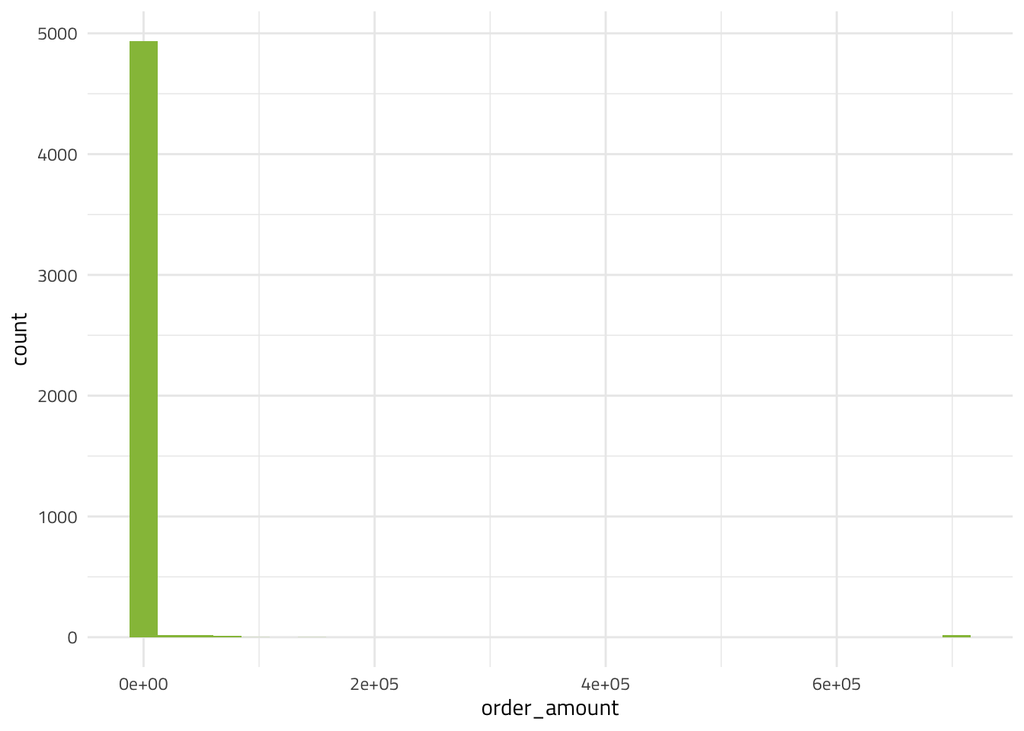

```r
data %>%
  ggplot() +
  geom_histogram(aes(x = order_amount), fill = "#96bf48") +
  labs("Order Amount ($)") +
  theme_cons
```

We can see from the histogram, it is apparent that there are big outliers skeweing the data, thus we don’t see much of a distribution in the histogram.

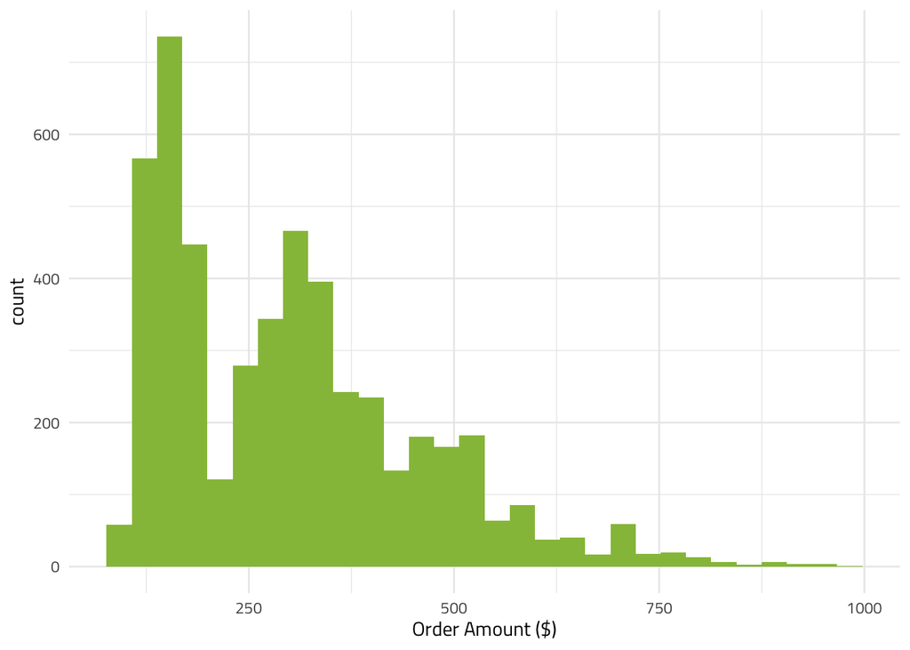

```r
data %>%
  filter(order_amount < 1000) %>%
  ggplot() +
  geom_histogram(aes(x = order_amount), fill = "#96bf48") +
  labs(x = "Order Amount ($)") +
  theme_cons
```

```r
data %>%
  group_by(shop_id) %>%
  summarize(amt = mean(order_amount),n = n()) %>%
  top_n(10, amt) %>%
  arrange(-amt)
```

```
## # A tibble: 10 x 3
##    shop_id     amt     n
##      <int>   <dbl> <int>
##  1      42 235101.    51
##  2      78  49213.    46
##  3      50    404.    44
##  4      90    403.    49
##  5      38    391.    35
##  6      81    384     59
##  7       6    384.    59
##  8      89    379.    61
##  9      33    376.    40
## 10      51    362.    46
```

Here, we can see that the data suffers from high outliers, where two shops are making vastly more money than the other shops. To mitigate the outliers in the mean, we can just use the median to get an estimate of the average order value.

```r
aov <- median(data$order_amount); aov
```

```
## [1] 284
```

Now, we get a more modest amount for a shoe store, which turned out to be 284.

# Question 2

1. SELECT COUNT(Orders.OrderID) FROM Orders, Shippers WHERE Orders.ShipperId = Shippers.ShipperID AND Shippers.ShipperName = “Speedy Express”
2. SELECT LastName FROM (SELECT Employees.LastName, count(Employees.LastName) as count FROM Employees, Orders WHERE Employees.EmployeeID = Orders.EmployeeID GROUP BY Employees.LastName) ORDER BY count DESC LIMIT 1
3. SELECT ProductName FROM Products WHERE ProductID = (SELECT ProductID FROM (SELECT ProductID, count FROM (SELECT ProductID, COUNT(ProductID) as count FROM Orders, Customers, OrderDetails WHERE Orders.CustomerID = Customers.CustomerID AND Orders.OrderID = OrderDetails.OrderID AND Country = ‘Germany’ GROUP BY ProductID) ORDER BY count DESC LIMIT 1))